# Über die t-Verteilung mit einem bzw. zwei Freiheitsgraden

Norman Markgraf

2021-02-17

## Vorbereitungen für R

Für die graphischen Ausgaben nutzen wir R und das Paket `mosaic`:

```r
library(mosaic)
```

## Vorbemerkungen und Notationen

Da alle t-Verteilungen symmetrisch sind, betrachten wir im wesendlichen nur den positiven Teil.

Zwei reelle Funktionen $f$, $g$ sind genau dann, im Sinne von de Bruijn[^1] (§1.4), **asymptotisch äquivalent** $f \sim g$, wenn

$$\lim\limits_{x \to \infty} \frac{f(x)}{g(x)} = 1$$

gilt.

Ist $f \sim g$, so können wir auch

$$f(x) = g(x)\cdot(1+o(1))$$

dafür schreiben. Dabei ist $h(x) = o(\phi(x))$ für $x \to \infty$, falls $\lim\limits_{x \to \infty} \frac{h(x)}{\phi(x)} = 0$ gilt. Aus der asymptotischen Äquivalenz von $f$ und $g$ folgt nun direkt:

$$\lim\limits_{x \to \infty}\frac{f(x)}{g(x)}-1 =\frac{f(x)-g(x)}{g(x)} = 0$$

Mit $h(x) = \frac{f(x)-g(x)}{g(x)}$ ist $h(x) = o(1)$ und daher $f(x)-g(x) = g(x)o(1)$ und schliesslich $f(x) = g(x)+g(x)o(1)$.

Ein wichtiges Korrolar sagt:

Ist $f \sim g$, so ist auch $\log(f) \sim \log(g)$.

## Die t-Verteilung im Allgemeinen

Die Dichtefunktion der t-Verteilung lauten im Allgemeinen:

$$f_n(x) = \frac{\Gamma\left(\frac{n+1}{2}\right)} {\sqrt{n\pi}~\Gamma\left(\frac{n}{2}\right)}\left(1+\frac{x^{2}}{n}\right)^{-\frac{n+1}{2}}\quad \mathrm{für}\quad -\infty < x < +\infty$$

wobei wir mit $\Gamma(x)$ die Gammafunktion

$$\Gamma(x)=\int\limits_{0}^{+\infty}t^{x-1}e^{-t}\operatorname{d}t$$

bezeichnen. Für einige $x$ nimmt die Gammafunktion leicht zu berechnende Werte an:

So ist für alle $n\in\mathbf{N_0}$:

$\Gamma(n+1) = n!$ und $\Gamma\left(n + \frac{1}{2}\right) = \frac{(2n)!}{n!4^n}\sqrt{\pi}$

mit der gewöhnlichen Fakultät $n! = \prod_{i=0}^n i$, wobei per Definition $0!=1$ ist.

## Die t-Verteilung mit einem Freiheitsgrad

Für $f_1(x)$ ergibt sich somit:

$$\begin{align*}
f_1(x) &= \frac{\Gamma\left(\frac{n+1}{2}\right)} {\sqrt{n\pi}~\Gamma\left(\frac{n}{2}\right)}\left(1+\frac{x^{2}}{n}\right)^{-\frac{n+1}{2}} \\
&= \frac{\Gamma\left(\frac{2}{2}\right)} {\sqrt{\pi}~\Gamma\left(\frac{1}{2}\right)}\left(1+x^{2}\right)^{-\frac{2}{2}} \\
&= \frac{\Gamma\left(1\right)} {\sqrt{\pi}~\Gamma\left(\frac{1}{2}\right)}\left(1+x^{2}\right)^{-1} \\
\end{align*}$$

Wegen $\Gamma(1) = 0! = 1$ und $\Gamma\left(\frac{1}{2}\right)=\sqrt{\pi}$ ergibt sich nun:

$$\begin{align*}
f_1(x) &= \frac{1} {\sqrt{\pi} \cdot \sqrt{\pi}} \cdot \left(1+x^{2}\right)^{-1} \\
&= \frac{1}{\pi} \cdot \frac{1}{1+x^{2}}
\end{align*}$$

Das ist die Dichtefunktion der standardisierten Cauchy-Verteilung

$$f_{(\mu,\lambda)}(x) = \frac{1}{\pi} \cdot \frac{\lambda}{\lambda^2+(x-\mu)^2}$$

mit ($\mu = 0$ und $\lambda=1$), welche – bekanntermaßen – keinen Erwartungwert hat.

Wegen

$$\begin{align*}
\lim_{x \to +\infty} \frac{f_1(k \cdot x)}{f_1(x)}
&= \lim_{x \to +\infty} \frac{\frac{1}{\pi} \cdot \frac{1}{1+(kx)^{2}}}{\frac{1}{\pi} \cdot \frac{1}{1+x^{2}}} = \lim_{x \to +\infty} \frac{1+x^2}{1+k^2x^2} \\
&=\lim_{x \to +\infty} \frac{\frac{1}{x^2}+\frac{x^2}{x^2}}{\frac{1}{x^2}+k^2\frac{x^2}{x^2}} =\frac{1}{k^2}=k^{-2}
\end{align*}$$

für alle reellen $k>0$ ist $f_1(x)$ eine regulär variierende Funktion mit Variationsindex $\rho = -2$.

Die Überlebensfunktion zur t-Verteilung mit einem Freiheitsgrad lautet nun:

$$\overline{F}_1(x) = \int_x^\infty f_1(t) \operatorname{d}t = \frac{1}{\pi} \cdot \int_x^\infty \frac{1}{1+x^{2}} \operatorname{d}t = \frac{\arctan(x)}{\pi}$$

da wir das optionale $+C$ mit $C=0$ annehmen dürfen.

Es gilt nun:

$$\arctan`(x)= \frac{1}{1+x^2} \to \frac{1}{x^2} \text{ für } x\to \infty$$

Genauer gilt wegen

$$\lim\limits_{x \to \infty} \frac{\frac{1}{1+x^2}}{\frac{1}{x^2}}
= \lim\limits_{x \to \infty} \frac{x^2}{1+x^2} =1,$$
dass $\frac{1}{1+x^2} \sim \frac{1}{x^2}$, also asymptotisch äquivalent sind und somit auch $\log\left(\frac{1}{1+x^2}\right) \sim \log\left(\frac{1}{x^2}\right)$.

Zusammen gefasst gilt somit:
$$\log\left(\frac{1}{\pi} \cdot \frac{1}{1+x^{2}}\right) \to -2\log(x) - \log(\pi) \text{ für } x \to \infty$$

Sei $f_1^*(x) = C \cdot x^{-\alpha}$ mit $\alpha = 2$ und $C=\frac{1}{\pi} \approx0.3183$.

Schauen wir uns das einmal als Grafik an:

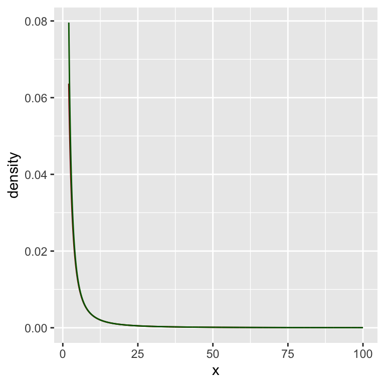

```r
lower_bound <- 2
upper_bound <- 100
dfree <- 1

f_star <- function(x) {
  alpha <- 2
  C <- 1/pi
  C * x**(-alpha)
}

x <- seq(lower_bound, upper_bound, 0.1)

gf_dist("t", df = dfree,
        xlim = c(lower_bound, upper_bound),
        color = "darkred") %>%
  gf_line(f_star(x) ~ x,
          color = "darkgreen")
```

Hier eine doppelt-logarithmische Darstellung:

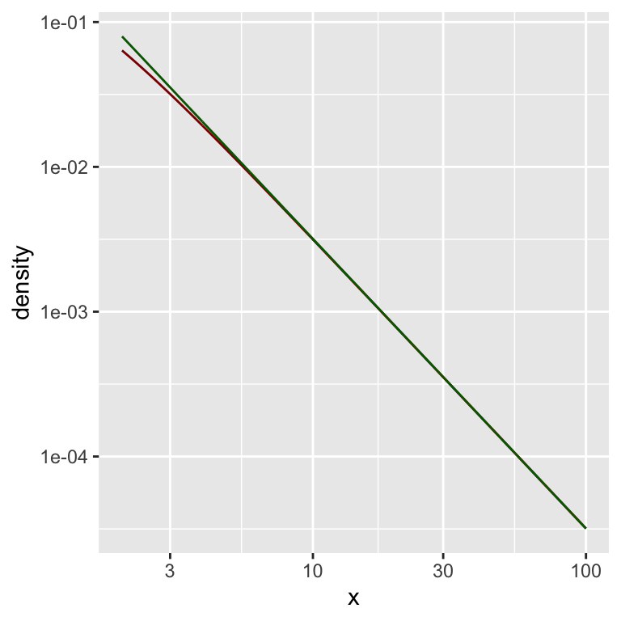

```r
gf_dist("t", df = dfree,
        xlim = c(lower_bound, upper_bound),
        color = "darkred") %>%
  gf_line( f_star(x) ~ x,
           color = "darkgreen") %>%
  gf_refine(
    scale_x_log10(),
    scale_y_log10()
  )
```

Wie groß ist nun der (absolute) Fehler zwischen $f_1^*$ und $f_1$?

```r
x <- seq(1,1000,1)
  gf_line(x**-2 - 1/(1+x**2) ~ x,
           color = "darkgreen") %>%
  gf_refine(
    scale_x_log10(),
    scale_y_log10()
  )
```

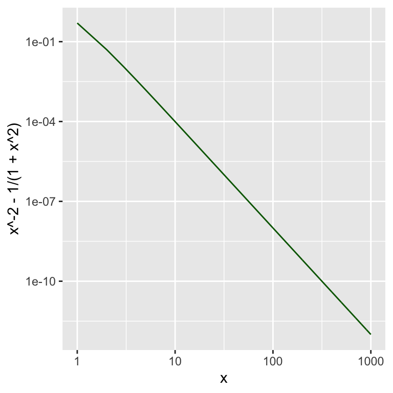

Genauer gilt:

$$f_1^*(x) - f_1(x) = \frac{1}{x^2+x^4}$$

Wir können also für ein hinreichend großes $x >> 1$ statt $f_1$ auch $f_1^*$ verwenden und erhalten somit:

$$\begin{align*}
\overline{F}_1(x) &\approx \int_x^\infty f_1^*(t) \operatorname{d}t
= \int_x^\infty C \cdot t^{-\alpha} \operatorname{d}t \\
&= \frac{1}{\pi} \cdot \int_x^\infty t^{-2} \operatorname{d}t
= \frac{1}{\pi}\left[\lim\limits_{\epsilon \to \infty} \left(-\epsilon^{-1}\right) -\left(-x^{-1}\right)\right]\\
&= \frac{1}{\pi}\cdot\left[0 + \frac{1}{x}\right] = \frac{1}{\pi \cdot x}
\end{align*}$$

**Wie hinreichend ist hier hinreichend groß?**

Taleb schreibt an dieser Stelle gerne, dass man jenseits des *Karamata-Punktes* die *Karamata-Konstante* anwenden kann. Beides Begriffe, die keine echte Definition haben und ausserhalb der Sphäre von Taleb auch kaum Verwendung finden.

Die *Karamata-Konstante* ist $\rho = -\alpha$.

Der *Karamata-Punkt* bleibt nebulös. Vermutlich könnte man hier so argumentieren:

Wenn die Fehler zwischen $f$ und $f^*$ hinreichend klein ist.

Hierfür könnte man einen absoluten Fehler oder einen relativen Fehler als Maßstab ansehen.

Für einen relativen Fehler vielleicht $\frac{f^*-f}{x} < k$?

Oder man betrachtet hier gleich $\frac{f^*-f}{\log(x)} < k^*$?

## t-Verteilung mit zwei Freiheitsgeraden

Für $f_2(x)$ ergibt sich somit:

$$\begin{align*}
f_2(x) &= \frac{\Gamma\left(\frac{n+1}{2}\right)} {\sqrt{n\pi}~\Gamma\left(\frac{n}{2}\right)}\left(1+\frac{x^{2}}{n}\right)^{-\frac{n+1}{2}} \\
&= \frac{\Gamma\left(\frac{3}{2}\right)} {\sqrt{2\pi}~\Gamma\left(\frac{2}{2}\right)}\left(1+\frac{x^{2}}{2}\right)^{-\frac{3}{2}} \\
&= \frac{\Gamma\left(\frac{3}{2}\right)} {\sqrt{2\pi}~\Gamma\left(1\right)}\left(1+\frac{x^{2}}{2}\right)^{-\frac{3}{2}} \\
\end{align*}$$

Wegen $\Gamma(1) = 0! = 1$ und $\Gamma\left(\frac{3}{2}\right)=\frac{\sqrt{\pi}}{2}$ ergibt sich nun:

$$\begin{align*}
f_2(x) &= \frac{1}{2\sqrt{2}} \cdot \left(1+\frac{x^{2}}{2}\right)^{-\frac{3}{2}} \\
&= \frac{1}{\sqrt[2]{2^3} \cdot \sqrt[2]{\left(1+\frac{x^{2}}{2}\right)^3}} \\
&= \frac{1}{(x^2+2)^{\frac{3}{2}}} \\
&= \frac{1}{\sqrt{(x^2+2)^3}}
\end{align*}$$

Wegen

$$\begin{align*}
\lim_{x \to +\infty} \frac{f_2(k \cdot x)}{f_2(x)}
&= \lim_{x \to +\infty} \frac{\frac{1}{\sqrt{((k\cdot x)^2+2)^3}}}{\frac{1}{\sqrt{(x^2+2)^3}}} = \lim_{x \to +\infty} \frac{\sqrt{(x^2+2)^3}}{\sqrt{((k\cdot x)^2+2)^3}} \\
&= \lim_{x \to +\infty} \left(\frac{x^2+2}{k^2x^2+2}\right)^\frac{3}{2}=\lim_{x \to +\infty} \left(\frac{\frac{x^2}{x^2}+\frac{2}{x^2}}{k^2\frac{x^2}{x^2}+\frac{2}{x^2}}\right)^\frac{3}{2} \\
&=\left(\frac{1}{k^2}\right)^\frac{3}{2}=\frac{1}{k^3}=k^{-3}
\end{align*}$$

für alle reellen $k>0$ ist $f_2(x)$ eine regulär variierende Funktion mit Variationsindex $\rho = -3$.

$$\begin{align*}
\overline{F}_2(x) &= \int_x^\infty f_2(t) \operatorname{d}t = \int_x^\infty \frac{1}{\sqrt{(t^2+2)^3}} \operatorname{d}t \\
&= \frac{x}{2 \cdot \sqrt{x^2+2}}
\end{align*}$$

da wir das optionale $+C$ mit $C=0$ annehmen dürfen.

Es gilt für jedes feste $k>0$:

$$\begin{align*}
\lim\limits_{x \to \infty} \frac{\overline{F}_2(k x)}{\overline{F}_2(x)} &= \lim\limits_{x \to \infty}k \cdot \sqrt{\frac{x^2+2}{k^2x^2+2}} \\
&= k \cdot \lim\limits_{x \to \infty} \sqrt{\frac{1}{k^2} \cdot \frac{x^2+2}{x^2+\frac{2}{k^2}}} \\
&= \frac{k}{k} \cdot \lim\limits_{x \to \infty} \sqrt{ \frac{x^2+2}{x^2+\frac{2}{k^2}}} = 1\end{align*}$$

Wegen

$$\lim_{x \to \infty} \frac{\frac{1}{\sqrt{(x^2+2)^3}}}{\frac{1}{x^3}} =\lim\limits_{x \to \infty} \frac{x^3}{(\sqrt{x^2+2})^3} = \lim\limits_{x \to \infty} \left(\frac{x}{\sqrt{x^2+2}}\right)^3= 1$$

ist $f_2 \sim f^*_2$ und somit auch $\log(f_2) \sim \log(f^*_2)$.

Aus $\log\left(\frac{1}{x^3}\right) = \log(1)- 3\cdot\log(x)$ können wir daher auf $\alpha = 3$ und $C=1$ schliesse und schreiben:

$$f_2^*(x) = C \cdot x^{-\alpha} = x^{-3}$$

Schauen wir uns das einmal als Grafik an:

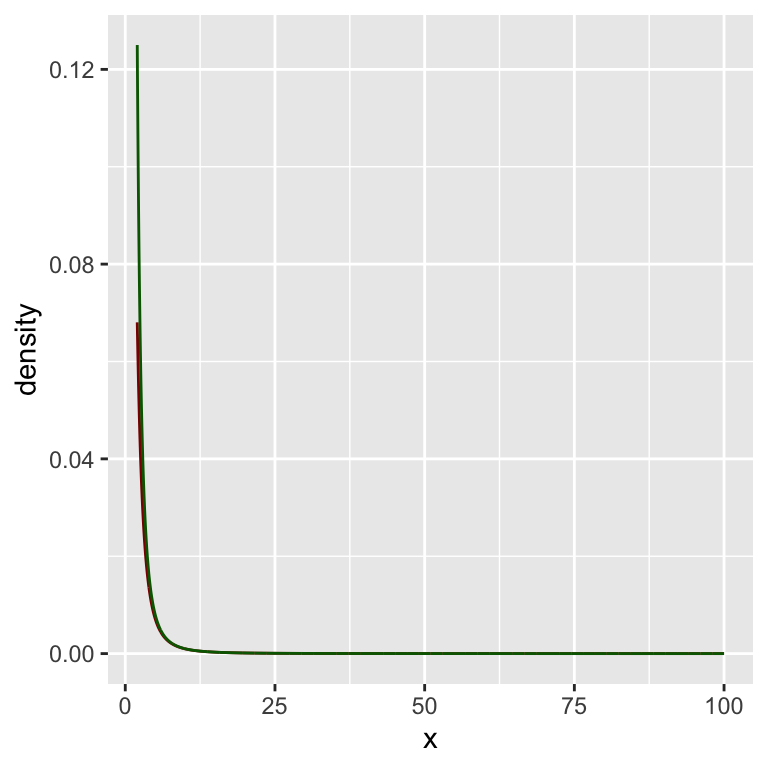

```r
lower_bound <- 2
upper_bound <- 100
dfree <- 2

f_star <- function(x) {
  alpha <- 3
  C <- 1
  C * x**(-alpha)
}

x <- seq(lower_bound, upper_bound, 0.1)

gf_dist("t", df = dfree,
        xlim = c(lower_bound, upper_bound),
        color = "darkred") %>%
  gf_line(f_star(x) ~ x,
          color = "darkgreen")
```

Hier eine doppelt-logarithmische Darstellung:

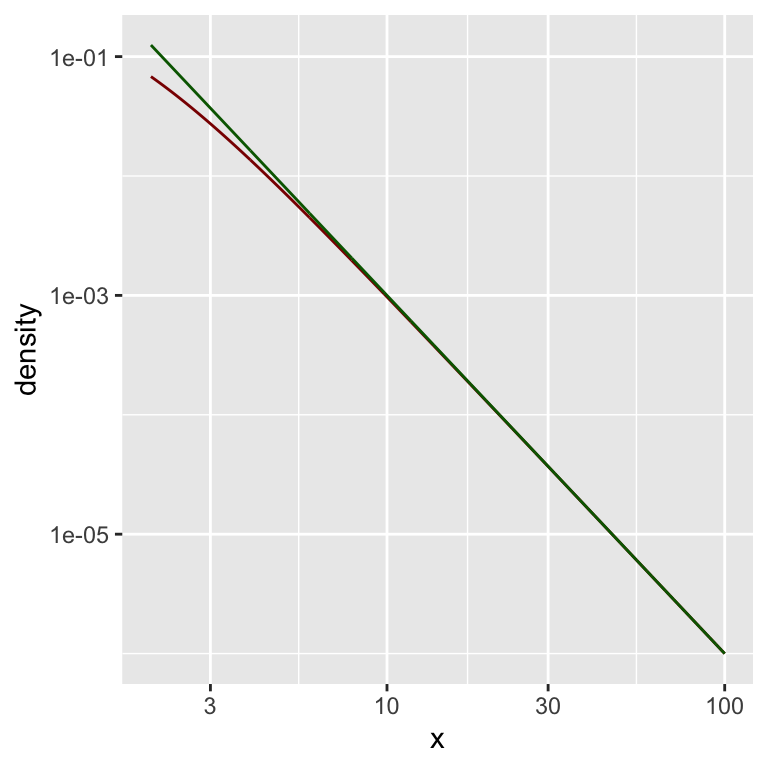

```r
gf_dist("t", df = dfree,
        xlim = c(lower_bound, upper_bound),
        color = "darkred") %>%
  gf_line( f_star(x) ~ x,
           color = "darkgreen") %>%
  gf_refine(
    scale_x_log10(),
    scale_y_log10()
  )
```

Wie groß ist nun der absolute Fehler zwischen $f_2^*$ und $f_2$ genau?

Eine Grafik zeigt von $f_2^*-2_1$ zeigt:

```r
x <- seq(1,1000,1)
  gf_line(f_star(x) - dt(x,df=2) ~ x,
           color = "darkgreen") %>%
  gf_refine(
    scale_x_log10(),
    scale_y_log10()
  )
```

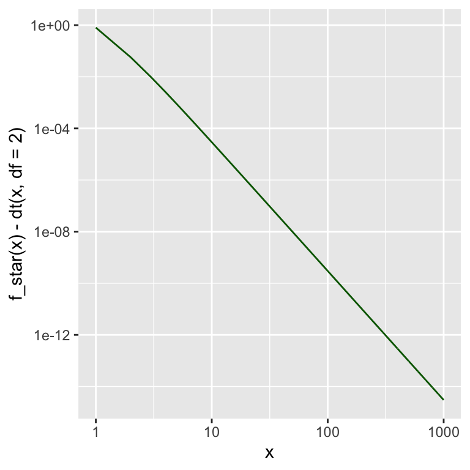

## Fussnoten

[^1]: [de Bruijn, N. G.](https://de.wikipedia.org/wiki/Nicolaas_Govert_de_Bruijn) (1981), [Asymptotic Methods in Analysis](https://books.google.com/books?id=Oqj9AgAAQBAJ), Dover Publications, ISBN 9780486642215